# Prediction Assignment - Practical Machine Learning

Marcelo Tibau

11 de novembro de 2016

# Executive Summary

Using devices such as Jawbone Up, Nike FuelBand, and Fitbit it is now possible to collect a large amount of data about personal activity relatively inexpensively. These type of devices are part of the quantified self movement - a group of enthusiasts who take measurements about themselves regularly to improve their health, to find patterns in their behavior, or because they are tech geeks. One thing that people regularly do is quantify how much of a particular activity they do, but they rarely quantify how well they do it. In this project, your goal will be to use data from accelerometers on the belt, forearm, arm, and dumbell of 6 participants. They were asked to perform barbell lifts correctly and incorrectly in 5 different ways. More information is available from the website here: http://groupware.les.inf.puc-rio.br/har (see the section on the Weight Lifting Exercise Dataset).

### Data source

The data for this project come from the Human Activity Recognition study, conducted by Pontifícia Universidade Católica - Rio de Janeiro. Read more: http://groupware.les.inf.puc-rio.br/har.

Ugulino, W.; Cardador, D.; Vega, K.; Velloso, E.; Milidiu, R.; Fuks, H. Wearable Computing: Accelerometers’ Data Classification of Body Postures and Movements. Proceedings of 21st Brazilian Symposium on Artificial Intelligence. Advances in Artificial Intelligence - SBIA 2012. In: Lecture Notes in Computer Science. , pp. 52-61. Curitiba, PR: Springer Berlin / Heidelberg, 2012. ISBN 978-3-642-34458-9. DOI: 10.1007/978-3-642-34459-6_6.

The training data for this project are available here:

https://d396qusza40orc.cloudfront.net/predmachlearn/pml-training.csv

The test data are available here:

https://d396qusza40orc.cloudfront.net/predmachlearn/pml-testing.csv

## Overview

This document contains two sections:

Analysis - where I provide the codes to download the cited training and testing datasets as well as clean them and also 3 machine learning algorithms - which regarding one different method of modeling.

# Analysis

Codes to load the libraries to be used:

```r
library("caret")
library("gbm")
```

```r
library("rpart")
library("rpart.plot")
library("RColorBrewer")
library("rattle")
library("randomForest")
```

Codes to download and read the train and test sets:

```r
download.file("https://d396qusza40orc.cloudfront.net/predmachlearn/pml-training.csv", dest="pml-training.csv", mode="wb")
download.file("https://d396qusza40orc.cloudfront.net/predmachlearn/pml-testing.csv", dest="pml-testing.csv", mode="wb")

dataTrain <- read.csv("pml-training.csv")
dataTest <- read.csv("pml-testing.csv")
head(dataTrain)
```

```
##   X user_name raw_timestamp_part_1 raw_timestamp_part_2   cvtd_timestamp
## 1 1  carlitos           1323084231               788290 05/12/2011 11:23
## 2 2  carlitos           1323084231               808298 05/12/2011 11:23
## 3 3  carlitos           1323084231               820366 05/12/2011 11:23
## 4 4  carlitos           1323084232               120339 05/12/2011 11:23
## 5 5  carlitos           1323084232               196328 05/12/2011 11:23
## 6 6  carlitos           1323084232               304277 05/12/2011 11:23
##   new_window num_window roll_belt pitch_belt yaw_belt total_accel_belt
## 1         no         11      1.41       8.07    -94.4                3
## 2         no         11      1.41       8.07    -94.4                3
## 3         no         11      1.42       8.07    -94.4                3
## 4         no         12      1.48       8.05    -94.4                3
## 5         no         12      1.48       8.07    -94.4                3
## 6         no         12      1.45       8.06    -94.4                3
##   kurtosis_roll_belt kurtosis_picth_belt kurtosis_yaw_belt
```

[output cut: 265 more lines]

```r
head(dataTest)
```

```
##   X user_name raw_timestamp_part_1 raw_timestamp_part_2   cvtd_timestamp
## 1 1     pedro           1323095002               868349 05/12/2011 14:23
## 2 2    jeremy           1322673067               778725 30/11/2011 17:11
## 3 3    jeremy           1322673075               342967 30/11/2011 17:11
## 4 4    adelmo           1322832789               560311 02/12/2011 13:33
## 5 5    eurico           1322489635               814776 28/11/2011 14:13
## 6 6    jeremy           1322673149               510661 30/11/2011 17:12
##   new_window num_window roll_belt pitch_belt yaw_belt total_accel_belt
## 1         no         74    123.00      27.00    -4.75               20
## 2         no        431      1.02       4.87   -88.90                4
## 3         no        439      0.87       1.82   -88.50                5
## 4         no        194    125.00     -41.60   162.00               17
## 5         no        235      1.35       3.33   -88.60                3
## 6         no        504     -5.92       1.59   -87.70                4
##   kurtosis_roll_belt kurtosis_picth_belt kurtosis_yaw_belt
```

[output cut: 265 more lines]

As we can see above, there’s some NA data in both datasets. I intend to proceed a cleaning of the dataset, but first I will partion the training set into two and check possibles Near Zero Variance Variables (it’s a necessity regarding the subject dataset, which has a great amount of Not Available datas, which I will refer as NA, and zero values).

Codes to partioning the training dataset into two: 70% for training and 30% for testing. I set seed to 13563 for reproducibility purposes.

```r
set.seed(13563)
inTrain <- createDataPartition(y=dataTrain$classe, p=0.7, list=FALSE)
training <- dataTrain[inTrain, ]
testing <- dataTrain[-inTrain, ]
dim(training)
```

```
## [1] 13737   160
```

```r
dim(testing)
```

```
## [1] 5885  160
```

Code to cheack possibles Near Zero Variance Variables:

```r
NZV_check <- nearZeroVar(training, saveMetrics = TRUE)
NZV_check
```

```
##                            freqRatio percentUnique zeroVar   nzv
## X                           1.000000  100.00000000   FALSE FALSE
## user_name                   1.104042    0.04367766   FALSE FALSE
## raw_timestamp_part_1        1.034483    6.09303341   FALSE FALSE
## raw_timestamp_part_2        1.000000   89.24073670   FALSE FALSE
## cvtd_timestamp              1.001914    0.14559220   FALSE FALSE
## new_window                 49.135036    0.01455922   FALSE  TRUE
## num_window                  1.034483    6.23134600   FALSE FALSE
## roll_belt                   1.077532    8.05124845   FALSE FALSE
## pitch_belt                  1.029412   12.16422800   FALSE FALSE
## yaw_belt                    1.064972   13.12513649   FALSE FALSE
## total_accel_belt            1.048561    0.20382907   FALSE FALSE
## kurtosis_roll_belt       1923.285714    1.95093543   FALSE  TRUE
## kurtosis_picth_belt       498.629630    1.58695494   FALSE  TRUE
## kurtosis_yaw_belt          49.135036    0.01455922   FALSE  TRUE
## skewness_roll_belt       2243.833333    1.93637621   FALSE  TRUE
## skewness_roll_belt.1      498.629630    1.68886948   FALSE  TRUE
## skewness_yaw_belt          49.135036    0.01455922   FALSE  TRUE
## max_roll_belt               1.125000    1.15017835   FALSE FALSE
## max_picth_belt              1.731707    0.15287181   FALSE FALSE
## max_yaw_belt              673.150000    0.41493776   FALSE  TRUE
## min_roll_belt               1.375000    1.10650069   FALSE FALSE
## min_pitch_belt              2.102564    0.10919415   FALSE FALSE
## min_yaw_belt              673.150000    0.41493776   FALSE  TRUE
## amplitude_roll_belt         1.120000    0.78619786   FALSE FALSE
## amplitude_pitch_belt        3.106383    0.09463493   FALSE FALSE
## amplitude_yaw_belt         51.385496    0.02911844   FALSE  TRUE
## var_total_accel_belt        1.344828    0.32758244   FALSE FALSE
## avg_roll_belt               1.000000    1.01186576   FALSE FALSE
## stddev_roll_belt            1.081081    0.36398049   FALSE FALSE
## var_roll_belt               1.692308    0.46589503   FALSE FALSE
## avg_pitch_belt              1.333333    1.20113562   FALSE FALSE
## stddev_pitch_belt           1.139535    0.24022712   FALSE FALSE
## var_pitch_belt              1.200000    0.32758244   FALSE FALSE
## avg_yaw_belt                1.142857    1.31032977   FALSE FALSE
## stddev_yaw_belt             2.032258    0.32030283   FALSE FALSE
## var_yaw_belt                1.108108    0.76435903   FALSE FALSE
## gyros_belt_x                1.036269    0.92451045   FALSE FALSE
## gyros_belt_y                1.119946    0.48773386   FALSE FALSE
## gyros_belt_z                1.100083    1.19385601   FALSE FALSE
```

[output cut: 106 more lines]

```
## stddev_pitch_forearm       29.500000    1.56511611   FALSE  TRUE
## var_pitch_forearm          59.000000    1.57239572   FALSE  TRUE
## avg_yaw_forearm            59.000000    1.57239572   FALSE  TRUE
## stddev_yaw_forearm         60.000000    1.56511611   FALSE  TRUE
## var_yaw_forearm            60.000000    1.56511611   FALSE  TRUE
## gyros_forearm_x             1.016043    2.06012958   FALSE FALSE
## gyros_forearm_y             1.062963    5.23403946   FALSE FALSE
## gyros_forearm_z             1.172205    2.16204411   FALSE FALSE
## accel_forearm_x             1.114754    5.68537526   FALSE FALSE
## accel_forearm_y             1.128571    7.11217879   FALSE FALSE
## accel_forearm_z             1.140000    4.03290384   FALSE FALSE
## magnet_forearm_x            1.019608   10.62823033   FALSE FALSE
## magnet_forearm_y            1.344262   13.21977142   FALSE FALSE
## magnet_forearm_z            1.113636   11.72017180   FALSE FALSE
## classe                      1.469526    0.03639805   FALSE FALSE
```

Codes to reset both training and testing sets without NZV:

```r
training <- training[, NZV_check$nzv==FALSE]
dim(training)
```

```
## [1] 13737   105
```

```r
NZV_check2 <- nearZeroVar(testing, saveMetrics = TRUE)
testing <- testing[, NZV_check2$nzv==FALSE]
dim(testing)
```

```
## [1] 5885  108
```

Theres a second transformation worth doing, which is removing the ID variable (the first column) so that it won’t interfer with Machine Learning Algorithms:

```r
training <- training[c(-1)]
testing <- testing[c(-1)]
```

I decided to clean the variables with more than 60% NAs.The threshold was chosen based at the 60% method, which I considered the most appropriate Training Threshold method for this particular dataset.

I also think worth to explain what’s going on: first, I will create a temporary subset to iterate in loop, then I will check for NA in every column in the dataset, select the columns under the 60% method and remove them.For closers, I will set it back to the proper dataset and remove the temp dataset. As you will see the code involved is plain logical reasoning.

Cleaning the training dataset:

```r
temp_train <- training
for (i in 1:length(training)) {
  if(sum(is.na(training[, i]))/nrow(training)>=0.6) {
    for (j in 1:length(temp_train)) {
      if(length(grep(names(training[i]), names(temp_train)[j]))==1){
        temp_train <- temp_train[, -j]
      }
    }
  }
}
dim(temp_train)
```

```
## [1] 13737    58
```

```r
training <- temp_train
rm(temp_train)
```

Cleaning the testing dataset:

```r
temp_test <- testing
for (i in 1:length(testing)) {
  if(sum(is.na(testing[, i]))/nrow(testing)>=0.6) {
    for (j in 1:length(temp_test)) {
      if(length(grep(names(testing[i]), names(temp_test)[j]))==1){
        temp_test <- temp_test[, -j]
      }
    }
  }
}
dim(temp_test)
```

```
## [1] 5885   58
```

```r
testing <- temp_test
rm(temp_test)
```

I chose to build 3 models. One model, using a random forest (“rf”) algorithm, the other, using a decision trees algorithm and a third, using a boosted trees algorithm - also known as generalized boosted regression (“gbm”).

Then, I intend to cross validate it predicting the outcomes and checking the accuracy of each model at the testing set.

Codes to build the models:

*Random Forest Algorithm*

```r
set.seed(13563)
modelFitRF <- randomForest(classe~., data = training)
```

Cross validating the model:

```r
predictFitRF <- predict(modelFitRF, testing, type = "class")
```

To check the accuracy:

```r
accuracy_FitRF <- confusionMatrix(predictFitRF, testing$classe)
accuracy_FitRF
```

```
## Confusion Matrix and Statistics
##
##           Reference
## Prediction    A    B    C    D    E
##          A 1674    3    0    0    0
##          B    0 1136    0    0    0
##          C    0    0 1026    5    0
##          D    0    0    0  958    1
##          E    0    0    0    1 1081
##
## Overall Statistics
##
##                Accuracy : 0.9983
##                  95% CI : (0.9969, 0.9992)
##     No Information Rate : 0.2845
##     P-Value [Acc > NIR] : < 2.2e-16
##
##                   Kappa : 0.9979
##  Mcnemar's Test P-Value : NA
##
## Statistics by Class:
##
##                      Class: A Class: B Class: C Class: D Class: E
## Sensitivity            1.0000   0.9974   1.0000   0.9938   0.9991
## Specificity            0.9993   1.0000   0.9990   0.9998   0.9998
## Pos Pred Value         0.9982   1.0000   0.9952   0.9990   0.9991
## Neg Pred Value         1.0000   0.9994   1.0000   0.9988   0.9998
## Prevalence             0.2845   0.1935   0.1743   0.1638   0.1839
## Detection Rate         0.2845   0.1930   0.1743   0.1628   0.1837
## Detection Prevalence   0.2850   0.1930   0.1752   0.1630   0.1839
## Balanced Accuracy      0.9996   0.9987   0.9995   0.9968   0.9994
```

The accuracy of the Random Forest model is 0.9983, a very good one. To facilitate the visualization, I intend to plot it.

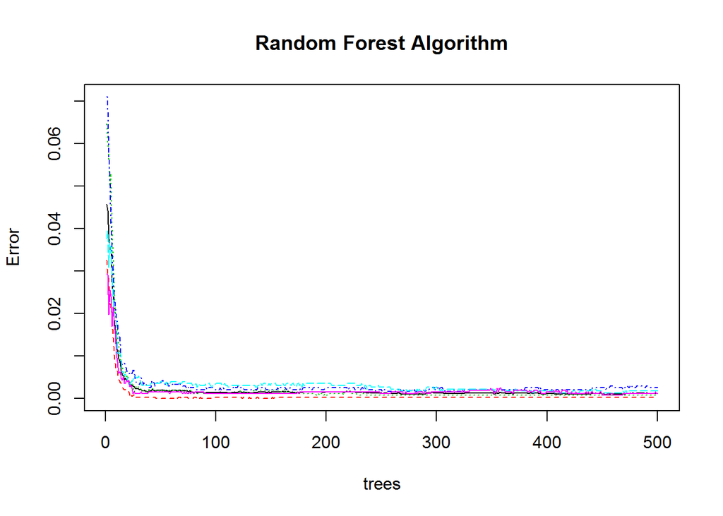

```r
plot(modelFitRF, main = "Random Forest Algorithm")
```

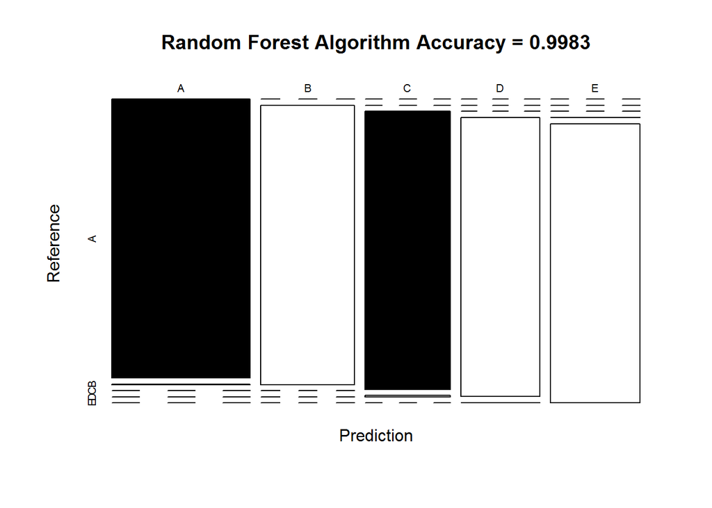

```r
plot(accuracy_FitRF$table, col = accuracy_FitRF$byClass, main = paste("Random Forest Algorithm Accuracy =", round(accuracy_FitRF$overall['Accuracy'], 4)))
```

*Decision Tree Algorithm*

[figure not shown]

```r
set.seed(13563)
modelFitDT <- rpart(classe ~., data = training, method = "class")
fancyRpartPlot(modelFitDT)
```

Cross validating the model:

```r
predictFitDT <- predict(modelFitDT, testing, type = "class")
```

To check the accuracy:

```r
accuracy_FitDT <- confusionMatrix(predictFitDT, testing$classe)
accuracy_FitDT
```

```
## Confusion Matrix and Statistics
##
##           Reference
## Prediction    A    B    C    D    E
##          A 1611   45    7    1    0
##          B   45  964   53   47    0
##          C   18  124  936  103   48
##          D    0    6   17  667   74
##          E    0    0   13  146  960
##
## Overall Statistics
##
##                Accuracy : 0.8731
##                  95% CI : (0.8643, 0.8815)
##     No Information Rate : 0.2845
##     P-Value [Acc > NIR] : < 2.2e-16
##
##                   Kappa : 0.8394
##  Mcnemar's Test P-Value : NA
##
## Statistics by Class:
##
##                      Class: A Class: B Class: C Class: D Class: E
## Sensitivity            0.9624   0.8464   0.9123   0.6919   0.8872
## Specificity            0.9874   0.9694   0.9397   0.9803   0.9669
## Pos Pred Value         0.9681   0.8693   0.7616   0.8730   0.8579
## Neg Pred Value         0.9851   0.9634   0.9807   0.9420   0.9744
## Prevalence             0.2845   0.1935   0.1743   0.1638   0.1839
## Detection Rate         0.2737   0.1638   0.1590   0.1133   0.1631
## Detection Prevalence   0.2828   0.1884   0.2088   0.1298   0.1901
## Balanced Accuracy      0.9749   0.9079   0.9260   0.8361   0.9271
```

The model accuracy rate is 0.8731. Not a bad one, but less than Random Forest’s. Again, in order to facilitate the visualization, a plot is needed.

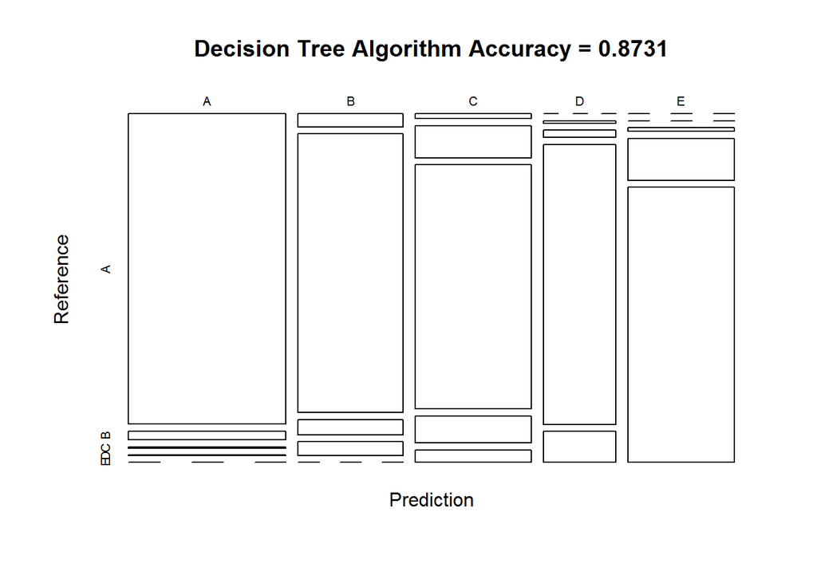

```r
plot(accuracy_FitDT$table, col = accuracy_FitDT$byClass, main = paste("Decision Tree Algorithm Accuracy =", round(accuracy_FitDT$overall['Accuracy'], 4)))
```

*Boosted Trees Algorithm*

To load the library needed and set seed to reproducibility.

```r
library(plyr)
set.seed(13563)
```

I usually don’t use the trainControl function from the caret package because one of its uses is allow to perform a variety of cross validation. As the Confusion Matrix and the predict function allow us to do the same, I usually don’t see the point to trainControl the model. However, in this case the model took too long to fit and almost “hijacked” my computer memory, so I used it to cut it short.

```r
FitControlGBM <- trainControl(method = "repeatedcv", number = 5, repeats = 1)

modelFitGBM <- train(classe~., data = training, method = "gbm", trControl = FitControlGBM, verbose = FALSE)

FinalmodelFitGBM <- modelFitGBM$finalModel
```

Cross validating the model:

```r
predictFitGBM <- predict(modelFitGBM, newdata = testing)
```

To check the accuracy:

```r
accuracy_FitGBM <- confusionMatrix(predictFitGBM, testing$classe)
accuracy_FitGBM
```

```
## Confusion Matrix and Statistics
##
##           Reference
## Prediction    A    B    C    D    E
##          A 1674    3    0    0    0
##          B    0 1133    0    0    0
##          C    0    2 1022    7    0
##          D    0    1    4  955    1
##          E    0    0    0    2 1081
##
## Overall Statistics
##
##                Accuracy : 0.9966
##                  95% CI : (0.9948, 0.9979)
##     No Information Rate : 0.2845
##     P-Value [Acc > NIR] : < 2.2e-16
##
##                   Kappa : 0.9957
##  Mcnemar's Test P-Value : NA
##
## Statistics by Class:
##
##                      Class: A Class: B Class: C Class: D Class: E
## Sensitivity            1.0000   0.9947   0.9961   0.9907   0.9991
## Specificity            0.9993   1.0000   0.9981   0.9988   0.9996
## Pos Pred Value         0.9982   1.0000   0.9913   0.9938   0.9982
## Neg Pred Value         1.0000   0.9987   0.9992   0.9982   0.9998
## Prevalence             0.2845   0.1935   0.1743   0.1638   0.1839
## Detection Rate         0.2845   0.1925   0.1737   0.1623   0.1837
## Detection Prevalence   0.2850   0.1925   0.1752   0.1633   0.1840
## Balanced Accuracy      0.9996   0.9974   0.9971   0.9947   0.9993
```

The accuracy of the model is rated at 0.9966. Although, comparing to Random Forest’s 0.9983 it’s not the best model. Once again, a plot to facilitate the visualization.

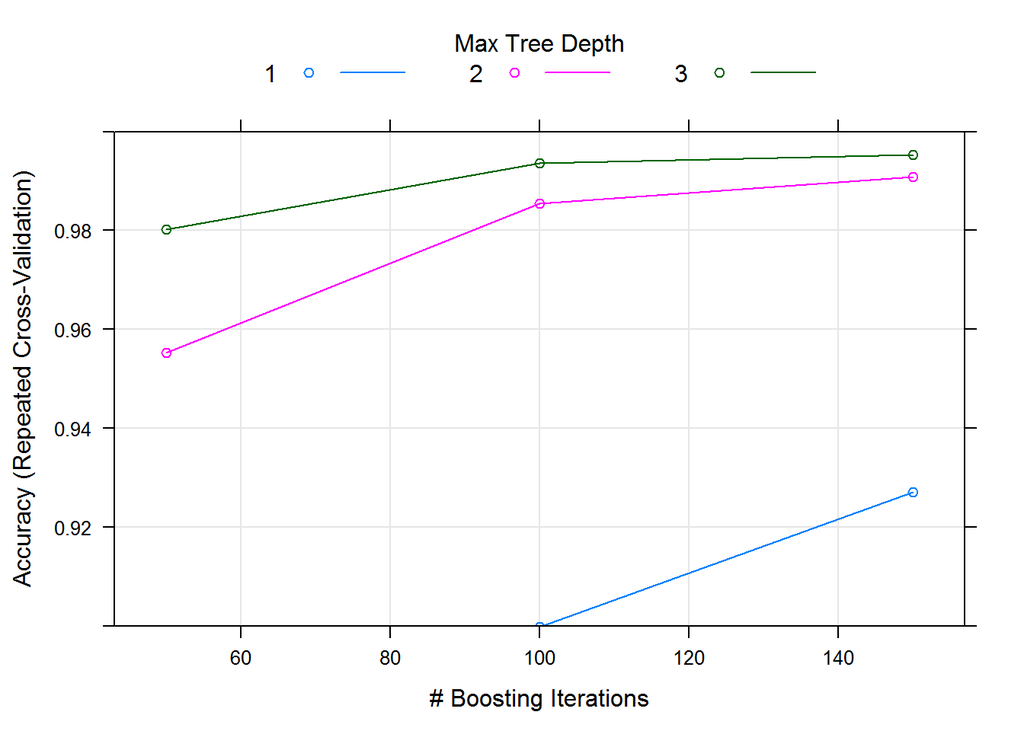

```r
plot(modelFitGBM, ylim = c(0.9, 1))
```

# Predicting Results

Code to proceed the prediction:

```r
prediction_results <- predict(modelFitRF, testing, type = "class")
prediction_results
```

[output not shown]

[output cut: 928 more lines]

[output not shown]

To generate file texts with predictions to submit for assignment. Here a warning is necessary, the code will create about 5,885 text files, so handle carefully.

```r
file_to_assignment <- function(x){
  n=length(x)
  for (i in 1:n) {
    filename = paste0("problem_id_", i, ".txt")
    write.table(x[i], file = filename, quote = FALSE, row.names = FALSE, col.names = FALSE)
  }
}
```

To create the files, use the function: file_to_assignment(prediction_results)